# Example: Poisson Regression

```julia
using DataFrames
using CSV
using Statistics
using Distributions
using Optim
using Plots
using StatsPlots
```

This is an example of setting up, fitting, checking, and modifying a generalized linear model (GLM). We’ll use a dataset of fish caught by visitors at a National Park:

```julia
fish = CSV.File("data/Fish.csv") |> DataFrame
fish[1:3, :]
```

3×6 DataFrame

| Row | fish_caught Int64 | livebait Int64 | camper Int64 | persons Int64 | child Int64 | hours Float64 |
| --- | --- | --- | --- | --- | --- | --- |
| 1 | 0 | 0 | 0 | 1 | 0 | 21.124 |
| 2 | 0 | 1 | 1 | 1 | 0 | 5.732 |
| 3 | 0 | 1 | 0 | 1 | 0 | 1.323 |

The data includes the number of fish caught by visitors, whether they used live bait, whether they brought a camper van, the number of children and persons in the party, and how many hours they spent in the park.

## Exploratory Analysis

Let’s plot a histogram of the number of caught fish (our response variable), as well as explore the relationship between the potential predictors and the response.

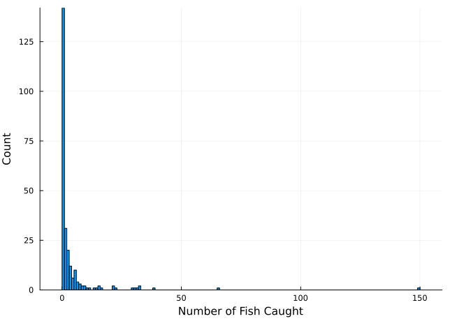

Figure 1: Histogram of the number of fish caught.

```julia
histogram(fish.fish_caught, xlabel="Number of Fish Caught", ylabel="Count", legend=false)
```

```julia
p1 = boxplot(fish.livebait, fish.fish_caught, xlabel="Live Bait Use", ylabel="Fish Caught", legend=false)
p2 = boxplot(fish.camper, fish.fish_caught, xlabel="Camper Van Use", ylabel="Fish Caught", legend=false)
p3 = boxplot(fish.child, fish.fish_caught, xlabel="Number of Children", ylabel="Fish Caught", legend=false)
p4 = boxplot(fish.persons, fish.fish_caught, xlabel="Number of Persons", ylabel="Fish Caught", legend=false)
p5 = scatter(fish.hours, fish.fish_caught, xlabel="Hours in Park", ylabel="Fish Caught", legend=false)
display(p1)
display(p2)
display(p3)
display(p4)
display(p5)
```

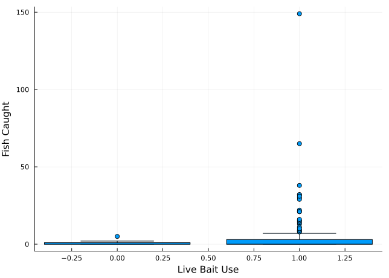

(a) Exploratory analysis of predictor variable relationship with the number of fish caught.

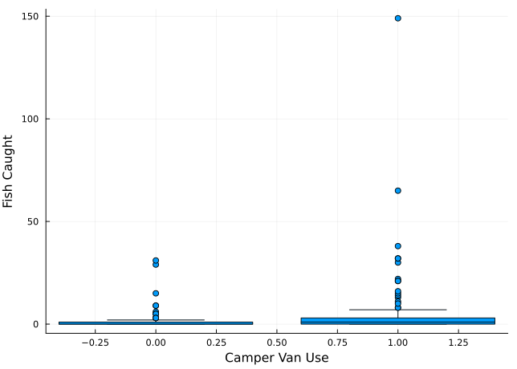

(b)

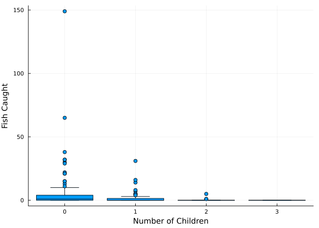

(c)

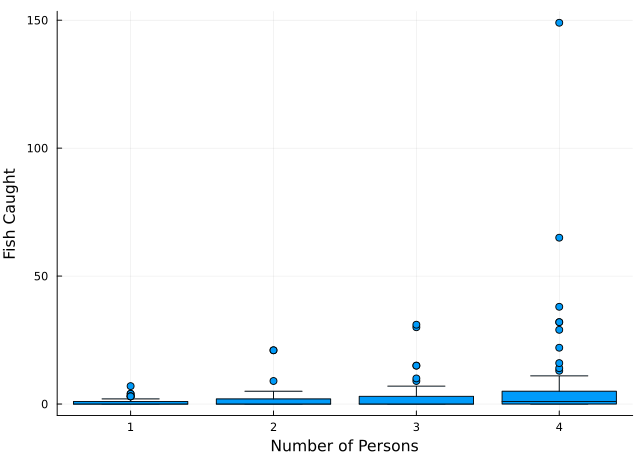

(d)

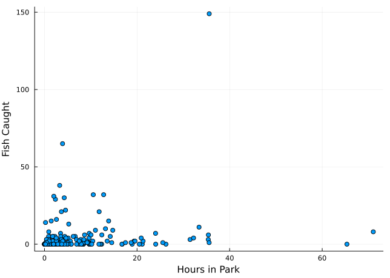

(e)

Figure 2

## Poisson Regression

### Model Specification

A GLM requires us to specify three things:

1. The distribution of the response variable $y$;
2. Link function(s) for the parameters which are modeled;
3. A linear model for the transformed parameters (through the reverse link).

From Figure 2, it appears as though there are relationships between the number of fish caught and the live bait, camper, child, and person variables, but not the number of hours (as groups might be doing something other than fishing for a while). The strongest impact are live bait and camper use, so let’s see how correlated these are to decide if we ought to include them as separate predictors.

```julia
@show sum(fish.camper[fish.livebait .== 0]) / nrow(fish);
@show sum(fish.camper[fish.livebait .== 1]) / nrow(fish);
@show sum(fish.livebait[fish.camper .== 0]) / nrow(fish);
```

```
sum(fish.camper[fish.livebait .== 0]) / nrow(fish) = 0.064
sum(fish.camper[fish.livebait .== 1]) / nrow(fish) = 0.524
sum(fish.livebait[fish.camper .== 0]) / nrow(fish) = 0.34
```

As a result, we might hypothesize that the number of fish caught is influenced by the number of children (noisy, distracting, impatient) and whether the party brought a camper. We’ll hold off on including the live bait variable for now. As we’re modeling counts of caught fish, a Poisson distribution is the typical starting point[^1], and the most flexible link for the Poisson rate $\lambda$ is the log. This would give us the following GLM:

$$\begin{align*}
y_i &\sim \text{Poisson}(\lambda_i) \\
f(\lambda_i) &= \beta_0 + \beta_1 \text{child}_i + \beta_2 \text{camper}_i
\end{align*}$$

### Fitting The Poisson Model

We’ll use numerical optimization to fit the model, using the basic optimization routine `Optim.optimize()`. We won’t tweak the settings and will give the optimizer a pretty broad range of parameters to work with.

```julia
function fish_model(params, child, camper, fish_caught)
    β₀, β₁, β₂ = params
    λ = exp.(β₀ .+ β₁ * child + β₂ * camper)
    ll = sum(logpdf.(Poisson.(λ), fish_caught))
    return ll
end

lb = [-100.0, -100.0, -100.0] # lower bounds
ub = [100.0, 100.0, 100.0] # upper bounds
init = [0.0, 0.0, 0.0] # initial guesses

optim_out = optimize(θ -> -fish_model(θ, fish.child, fish.camper, fish.fish_caught), lb, ub, init)
θ_mle = optim_out.minimizer
@show round.(θ_mle; digits=2);
@show round.(exp.(θ_mle); digits=2);
```

```
round.(θ_mle; digits = 2) = [0.91, -1.23, 1.05]
round.(exp.(θ_mle); digits = 2) = [2.48, 0.29, 2.87]
```

So, **under this model specification**, the base odds of catching a fish are 2.5, which are decreased by a factor of 0.29 for every additional child in the group, and increased by a factor of almost 3 if a camper is used. How do we know if this model works well?